# Lab 3: Visualization with ggplot2

This week we introduced how to make more esthetically pleasing plots using `ggplot2`. For the remainder of the course you’ll be expected to use `ggplot2` any time you create a plot. Many more plotting examples will be presented in class, but let’s get more practice now.

Recall this figure from the `intro-to-ggplot.Rmd` lecture file:

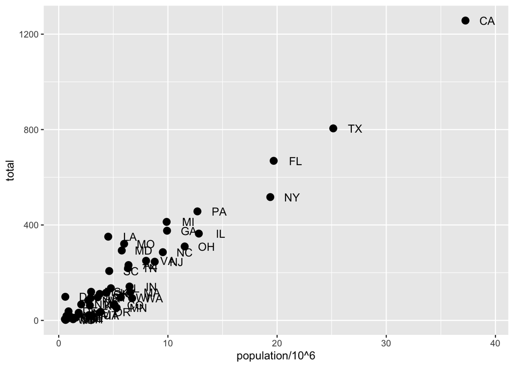

Remake the plot above but

1. flip the variables so that `total` is in the x-axis and `population` is in the y-axis
2. show the state names instead of the abbreviation
3. make the points smaller

```r
#Your code here.
```

### Grids of plots

Rather than using `facet_wrap` or `facet_grid`, there is another option for graphing plots next to each other: the `gridExtra` package permits us to do that. First create and name all of the plots you wish to show in the same window. Then use the function `grid.arrange()` and specificy which plots you want to include and how many columns you want to organize them in.

Below is an example using the `heights` data set. We define `p` to be a histogram of male heights and `p1`, `p2`, and `p3` to be the same histogram but with different binwidths i.e. different widths for the rectangles that make up the histogram.

```r
p <- heights %>% filter(sex == "Male") %>%
                 ggplot(aes(x = height))

p1 <- p + geom_histogram(binwidth = 1, fill = "blue", col="black")
p2 <- p + geom_histogram(binwidth = 2, fill = "blue", col="black")
p3 <- p + geom_histogram(binwidth = 3, fill = "blue", col="black")
```

To print them all side-by-side, we can use the function `grid.arrange` in the `gridExtra` package:

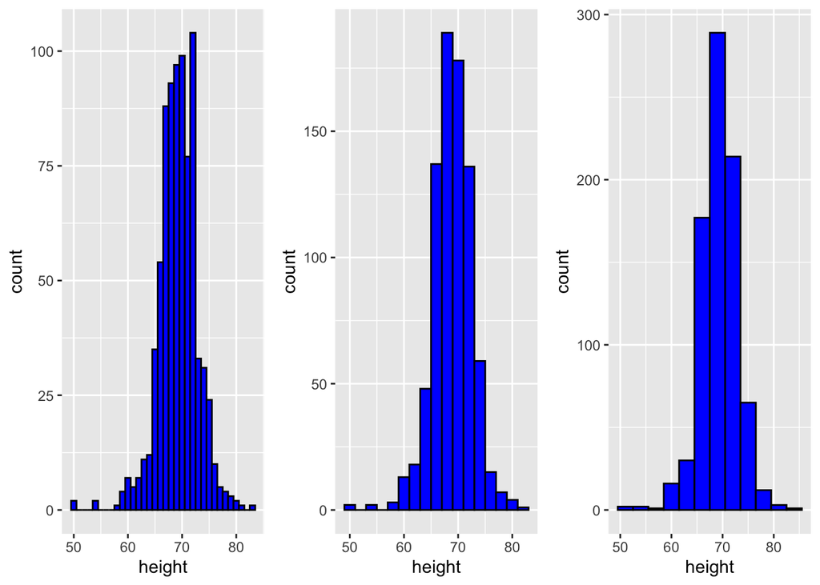

```r
library(gridExtra)
grid.arrange(p1,p2,p3, ncol = 3)
```

Here, `ncol` specifies how many columns I want to arrange my plot in.

4. Using the `gapminder` dataset, filter the data frame so only data from the year 2015 is kept.

```r
#Your code here.
```

5. Create a histogram of `fertility`, and a second histogram of `life expectancy`. Then use `grid.arrange()` to plot the histograms on top of each other in the same window.

```r
#Your code here.
```

## Vaccines

For homework #2 you’ll be working with the `us_contagious_diseases` dataset in the `dslabs` package. The data were collected, organized and distributed by the [Tycho Project](https://www.tycho.pitt.edu/). They include weekly reported counts data for seven diseases from 1928 to 2011, from all fifty states. We include the yearly totals in the `dslabs` package:

```r
library(dslabs)
data("us_contagious_diseases")
```

6. Use the `us_contagious_disease` dataset and `dplyr` tools to create an object called `dat` that stores only the Smallpox data, includes a per 10,000 people rate, and removes Alaska and Hawaii since they only became states in the late 1950s. Include years in which cases were reported in 10 or more weeks.

```r
#Your code here.
```

7. Calculate the US average number of cases of Smallpox per 10,000 people for each year. Do not include years in which cases were not reported.

```r
#Your code here.
```

8. Make a the time series plot of the number of cases of Smallpox per 10,000 people for all states and add a line for the US average.

```r
#Your code here.
```

9. For the state of California, make a time series plot showing rates for all diseases. Include only years with 10 or more weeks reporting. Use a different color for each disease.

```r
#Your code here.
```